# Data Wrangling Main

Laura Palacios

2022-12-23

# R Data wrangling

This r teaching session will introduce data wrangling tasks which commonly occur in National Park Service activities.

We will cover:

0. Awards and Accolades!
1. Review of GitHub - retrieving this document from space!
2. Importing a CSV as a data frame
3. Viewing the file
4. The Question!
5. Data clean up
- 1. Tidy column names
- 2. Clean up missing data
- 3. Filter data
- 4. Convert column data type
- 5. Change column layout

## 0. Awards and Accolades!

[figure not shown]

Congratulations to Rachel, Kara, Carolyn, Rebecca, Ann, Jessica, Helen, and Anna: our Golden Bison recipients. These individuals all successfully competed the second SWNC training on Github.

## 1. GitHub Review

1. Send Laura your GitHub username so that she can give you editing access to the repo.

   *Note for recording listeners*: You can still complete this training without repo editing access. If you prefer, complete only GitHub Review steps 4 and 5 to download a local, editable copy of the training to your machine. The only difference is that you will not be able to push your completed training back onto GitHub.
2. Go to the location of the repository at https://github.com/palacila/SWNC_3_Data_Wrangling.
3. Click on the **main dropdown** in the upper left, and begin typing your name separated by underscores. Once complete, click on **‘Create branch:*your name* from main’**. This will create your branch!

[figure not shown]

4. Clone the Repo Click on **code** in the upper right, and copy the HTTPS url provided.

[figure not shown]

5. Open R Studio. Go to **File>NewProject>VersionControl>Git** . Paste the repository URL. Information and download location should auto-populate. Click **Create Project**.
6. Switch to your branch in R studio.

   Navigate to the Git Panel (upper right) in RStudio. If it is not there, you can go to **View >ShowGit** to view it. Click the drop down menu in the upper right and select your branch name to switch to your branch!

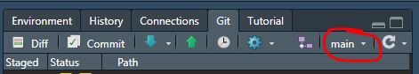

7. Open the RMD file titled **Data_Wrangling_Learner.RMD** by using the file tab in the lower right corner of R studio.

   We will be filling in the blanks of this document, then pushing the completed RMD files back onto GitHub. Please note that **Data_Wrangling_Main.RMD** is a completed copy of this lesson plan which can be used as reference.

   Please fill in the author section of the header now.

## 2. Importing a CSV as a data frame

**To do** If you do not have csv installed, use **install.packages(“csv”)** in the console to install.

**To do** Load the library by using library()

```r
# Do not fear the notifications. This is expected.
library(csv)
```

Import the file

What file types can be imported? Most file types will have their own library to make it easy to bring the data into R studio. Unsure what to use? Google “r read in file-type” to find the appropriate library.

We will be using a CSV file for this training, found here: [Groundhog data](https://www.kaggle.com/datasets/groundhogclub/groundhog-day). The file has already been placed into the data folder of this repo.

**To do** Use the read.csv() function to read in the csv from the data folder. Use <- to assign it to the variable name groundhog_raw

```r
# Import the dataset
groundhog_raw <- read.csv("data/Groundhog_Data.csv")
```